# E:\study\作业

### 统计学：检验心理学现象

在下方单元格中回答问题并执行相关代码，你可以 参考项目指导 并在正式提交前查看 [项目要求](https://review.udacity.com/#!/rubrics/305/view)。提交时请将 Jupyter notebook 导出成 HTML 或者 PDF 进行提交（File -> Download As）。

背景信息

在一个Stroop （斯特鲁普）任务中，参与者得到了一列文字，每个文字都用一种油墨颜色展示。参与者的任务是将文字的打印颜色大声说出来。这项任务有两个条件：一致文字条件，和不一致文字条件。在一致文字条件中，显示的文字是与它们的打印颜色匹配的颜色词，如“红色”、“蓝色”。在不一致文字条件中，显示的文字是与它们的打印颜色不匹配的颜色词，如“紫色”、“橙色”。在每个情况中，我们将计量说出同等大小的列表中的墨色名称的时间。每位参与者必须全部完成并记录每种条件下使用的时间。

调查问题

作为一般说明，请确保记录你在创建项目时使用或参考的任何资源。作为项目提交的一部分，你将需要报告信息来源。

(1) 我们的自变量是什么？因变量是什么？

自变量：显示的文字颜色与它们的打印颜色的颜色词是否相同 因变量：实验者说出同等大小的列表中的墨色名称的时间

(2) 此任务的适当假设集是什么？你需要以文字和数学符号方式对假设集中的零假设和对立假设加以说明，并对数学符号进行定义。你想执行什么类型的统计检验？为你的选择提供正当理由（比如，为何该实验满足你所选统计检验的前置条件）。

假设集：μsame = 实验者说出显示的文字颜色与它们的打印颜色的颜色词相同情况下的时间 μdiffer = 实验者说出显示的文字颜色与它们的打印颜色的颜色词不相同情况下的时间

零假设：μsame = μdiffer，即自变量的改变不会影响因变量 对立假设：μsame != μdiffer，即自变量的改变会影响因变量

使用t检验，且用双尾校验。 因为本次使用的试验数据集检验对象是同一样本数据进行两种不同条件的处理，属于配对样本t检验，且由于备择假设中包含不等号，我们需要找出参数的变化，而不是增减，所以选用双尾检验。

现在轮到你自行尝试 Stroop 任务了。前往此链接，其中包含一个基于 Java 的小程序，专门用于执行 Stroop 任务。记录你收到的任务时间（你无需将时间提交到网站）。现在下载此数据集，其中包含一些任务参与者的结果。数据集的每行包含一名参与者的表现，第一个数字代表他们的一致任务结果，第二个数字代表不一致任务结果。

(3) 报告关于此数据集的一些描述性统计。包含至少一个集中趋势测量和至少一个变异测量。

```python
# 在这里执行你的分析
import pandas as pd
import scipy.stats as stats
df = pd.read_csv('stroopdata.csv')
df.describe()
```

|  | Congruent | Incongruent |
| --- | --- | --- |
| count | 24.000000 | 24.000000 |
| mean | 14.051125 | 22.015917 |
| std | 3.559358 | 4.797057 |
| min | 8.630000 | 15.687000 |
| 25% | 11.895250 | 18.716750 |
| 50% | 14.356500 | 21.017500 |
| 75% | 16.200750 | 24.051500 |
| max | 22.328000 | 35.255000 |

```python
df.median()
```

```
Congruent      14.3565
Incongruent    21.0175
dtype: float64
```

```python
stats.iqr(df,axis=0)
```

```
array([ 4.3055 ,  5.33475])
```

```python
#计算极差
df.Congruent.ptp(),df.Incongruent.ptp()
```

```
(13.698000000000002, 19.568000000000001)
```

```python
stats.mode(df)[0][0]
```

```
array([  8.63 ,  15.687])
```

--答案写这里-- 集中趋势测量:

Congruent: 均值: 14.05 中位数: 14.36

Incongruent: 均值: 22.02 中位数: 21.02

变异测量:

Congruent: 样本标准偏差: 3.56 极差：13.698000000000002 IQR：4.3055

Incongruent: 样本标准偏差: 4.80 极差：19.568000000000001 IQR：5.33475

(4) 提供显示样本数据分布的一个或两个可视化。用一两句话说明你从图中观察到的结果。

```python
import numpy as np
import matplotlib.pyplot as plt
```

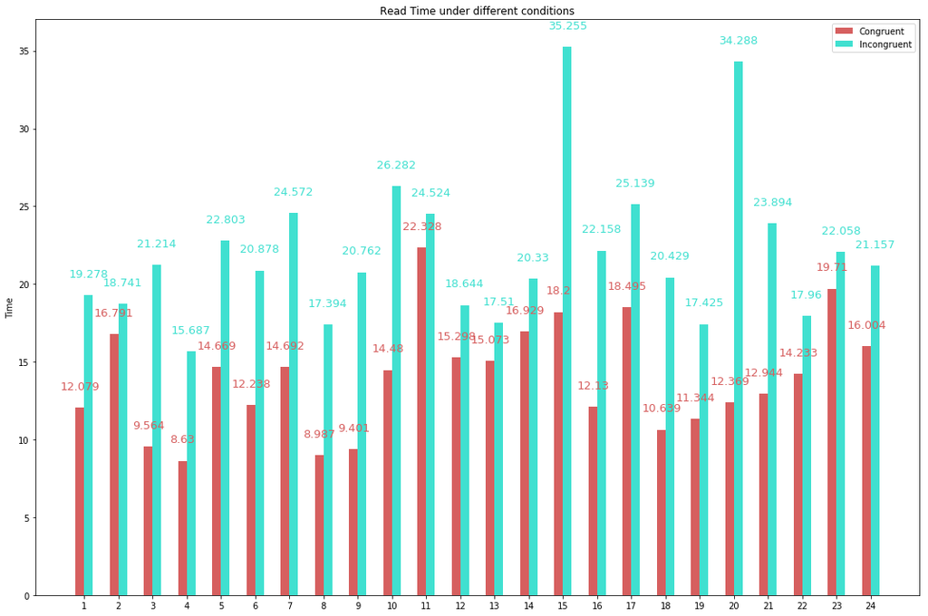

```python
# 在这里创建可视化图表
df.index = range(0, len(df.Congruent))
bar_width = 0.5
x_pos = np.arange(len(df.Congruent) * 2, step = 2)

plt.figure(figsize=[15,10]) #建立图像
plt.bar(x_pos, df['Congruent'], color = '#d65f5f', width = bar_width)
plt.bar(x_pos + bar_width, df['Incongruent'], color = 'Turquoise', width = bar_width)
plt.xticks(x_pos + bar_width / 2, df.index + 1)
plt.title("Read Time under different conditions")
for x,y, z in zip(x_pos, df['Congruent'], df['Incongruent']):
    plt.text(x, y + 1, str(round(y,3)), ha='center', va='bottom', fontsize = 13, rotation = 0, color = '#d65f5f')
    plt.text(x + bar_width, z + 1, str(round(z,3)), ha='center', va='bottom', fontsize = 13, rotation = 0, color = 'Turquoise')
plt.ylabel("Time")
#print(df.columns)
plt.legend(df.columns)
plt.tight_layout()
plt.show()
```

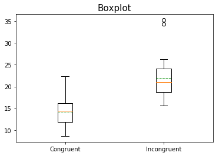

```python
data = [df.Congruent, df.Incongruent]
plt.title('Boxplot', fontsize = 15)
plt.boxplot(data,labels = df.columns, showmeans = True, meanline= True)
plt.show()
```

(5) 现在，执行统计测试并报告你的结果。你的置信水平和关键统计值是多少？你是否成功拒绝零假设？对试验任务得出一个结论。结果是否与你的期望一致？

```python
# 在这里执行统计检验
#使用stats的配对样本t检验计算p-value
stats.ttest_rel(df.Congruent,df.Incongruent,axis=0)
```

```
Ttest_relResult(statistic=-8.020706944109957, pvalue=4.1030005857111781e-08)
```

--答案写这里-- 选择置信水平为95%，因为pvalue远小于0.05，所以选择拒绝零假设，接受备择假设，即显示的文字与它们的打印颜色不匹配时对实验者的阅读时间会产生影响。